# Recommender Systems

How a modern recommender picks your next video: embeddings and retrieval

Son Nguyen

## Today: One Recommendation, Start to Finish

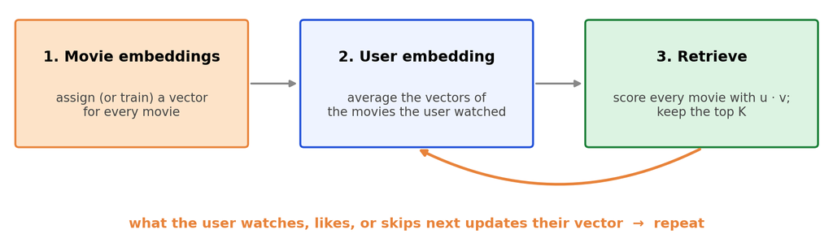

- A recommender answers one question: **what will this person want next?**
- Today: follow **the user** through the loop by hand, with 8 movies.

**Similar things are close together.** Recommend the movies closest to the person.

**Simplified version, small enough to do by hand.** Real systems use the same ideas at full scale: hundreds of learned numbers per item, millions of items, and large neural networks.

## The Recommendation Problem

| Movie |
| --- |
| Elf |
| Paddington |
| John Wick |
| Mad Max |
| Shrek |
| The Incredibles |
| The Notebook |
| Titanic |

- **The user**, and a catalog of **8 movies**.
- The user has already seen a few of them.
- **Question:** which movie should the user watch **next**?
- A **recommender system (RS)** answers this for every user: rank the movies they have not seen and show the top few.

**Goal:** a short, ranked list of movies the user is likely to want next.

Two ways to build it: the **old approach** (ratings + KNN) and the **modern approach** (behavior + embeddings).

# Part 1. The Old Approach: Ratings and KNN

## Old Approach, Step 1: Collect Ratings

| Movie | **The user** | User 1 | User 2 | User 3 | User 4 |
| --- | --- | --- | --- | --- | --- |
| Elf | ? | 5 | 4 | 2 | 1 |
| Paddington | **5** | 5 | 4 | 2 | 1 |
| John Wick | ? | 3 | 4 | – | 5 |
| Mad Max | ? | – | 3 | 1 | 5 |
| Shrek | **5** | 4 | 5 | 2 | 3 |
| The Incredibles | ? | 5 | 5 | 2 | 4 |
| The Notebook | ? | 1 | 2 | 5 | – |
| Titanic | **2** | 2 | 1 | 5 | 3 |

- Users give **1 to 5 stars** to movies they have seen.
- The user rated **3** movies: Paddington 5, Shrek 5, Titanic 2.
- **?** = the user’s unknown ratings: the 5 movies they have not seen. **–** = not rated.
- **Task:** predict each **?**, then recommend the highest.

## Old Approach, Step 2: Find the User’s Nearest Neighbors (KNN)

Compare the user with every other user on the movies **the user rated** (Paddington, Shrek, Titanic), using **cosine similarity**: $\cos(\mathbf{a}, \mathbf{b}) = \dfrac{\mathbf{a}\cdot\mathbf{b}}{\lVert\mathbf{a}\rVert\,\lVert\mathbf{b}\rVert}$ (1 = same pattern of ratings; larger = more similar).

| User | Ratings | Cosine with the user (5, 5, 2) | Cosine | K = 2 |
| --- | --- | --- | --- | --- |
| User 1 | (5, 4, 2) | $\dfrac{5(5) + 5(4) + 2(2)}{\sqrt{5^2 + 5^2 + 2^2}\,\sqrt{5^2 + 4^2 + 2^2}}$ | **0.994** | **neighbor** |
| User 2 | (4, 5, 1) | $\dfrac{5(4) + 5(5) + 2(1)}{\sqrt{5^2 + 5^2 + 2^2}\,\sqrt{4^2 + 5^2 + 1^2}}$ | **0.987** | **neighbor** |
| User 4 | (1, 3, 3) | $\dfrac{5(1) + 5(3) + 2(3)}{\sqrt{5^2 + 5^2 + 2^2}\,\sqrt{1^2 + 3^2 + 3^2}}$ | **0.812** |  |
| User 3 | (2, 2, 5) | $\dfrac{5(2) + 5(2) + 2(5)}{\sqrt{5^2 + 5^2 + 2^2}\,\sqrt{2^2 + 2^2 + 5^2}}$ | **0.711** |  |

- **Nearest neighbors: User 1 and User 2** (largest cosine). Their ratings look most like the user’s: they like the same movies.

- This is the **KNN** you know, with similarity instead of distance: keep the $K$ **most similar**. Here the points are **users**, described by their ratings.

**Why not the plain dot product here?** On raw stars it rewards **generous raters**: someone who gives everything 5★ would score $5(5) + 5(5) + 2(5) = 60$, beating User 1, even though they disagree on Titanic. Cosine divides by the lengths, so only the **pattern** counts.

## Old Approach, Step 3: Predict the User’s Ratings, Then Recommend

| Movie the user has not seen | User 1 | User 2 | Predicted rating = neighbors’ average | Recommend |
| --- | --- | --- | --- | --- |
| The Incredibles | 5 | 5 | (5 + 5) / 2 = **5** | **#1 ✓** |
| Elf | 5 | 4 | (5 + 4) / 2 = **4.5** | **#2 ✓** |
| John Wick | 3 | 4 | (3 + 4) / 2 = **3.5** | **#3 ✓** |
| Mad Max | – | 3 | 3 (only User 2 rated it) = **3** |  |
| The Notebook | 1 | 2 | (1 + 2) / 2 = **1.5** |  |

**Recommend: The Incredibles, Elf, John Wick** (the highest predicted ratings).

This was the method of the 2000s: **user-based collaborative filtering** (GroupLens, early Amazon and Netflix).

## Old Approach, Another Way: Item-Based KNN

**Flip the table.** Each **movie** is a point, described by the ratings the **other users** gave it:

| Movie | User 1 | User 2 | User 3 | User 4 |
| --- | --- | --- | --- | --- |
| **The Incredibles** | 5 | 5 | 2 | 4 |
| **Shrek** | 4 | 5 | 2 | 3 |

Cosine similarity of the two movies:
$$\frac{5(4) + 5(5) + 2(2) + 4(3)}{\sqrt{5^2 + 5^2 + 2^2 + 4^2}\,\sqrt{4^2 + 5^2 + 2^2 + 3^2}} = 0.992$$
Close to 1: **the same people liked both**.

- **User-based** (Steps 2–3): find **users** like the user, average **their** ratings.
- **Item-based**: for each movie the user has **not** seen, find the $K = 2$ **most similar movies the user rated**, and average **the user’s own** ratings of them.
- Compare two movies with **cosine similarity**, only over users who rated **both** (skip the –).

Same KNN, new points: **movies instead of users**. This is Amazon’s “customers who bought this also bought” (item-to-item, 2003).

## Item-Based Step 2: Similarity Between Movies

Cosine similarity of each movie the user has not seen with each movie the user rated (over the other users who rated both). The $K = 2$ most similar are in **bold**.

| Movie the user has not seen | with Paddington (user: 5★) | with Shrek (user: 5★) | with Titanic (user: 2★) | 2 most similar movies |
| --- | --- | --- | --- | --- |
| Elf | **1** | **0.943** | 0.637 | Paddington and Shrek |
| John Wick | 0.786 | **0.94** | **0.945** | Titanic and Shrek |
| Mad Max | **0.701** | **0.877** | 0.657 | Shrek and Paddington |
| The Incredibles | **0.934** | **0.992** | 0.708 | Shrek and Paddington |
| The Notebook | 0.626 | **0.653** | **0.967** | Titanic and Shrek |

- Example: *Mad Max* with *Shrek* uses User 2, User 3, User 4 (User 1 did not rate *Mad Max*): $\dfrac{3(5) + 1(2) + 5(3)}{\sqrt{3^2 + 1^2 + 5^2}\,\sqrt{5^2 + 2^2 + 3^2}} = 0.877$.

- *Elf* and *Paddington* have cosine **1**: every other user gave them the same rating.

## Item-Based Step 3: Predict the User’s Ratings, Then Recommend

| Movie the user has not seen | 2 most similar movies the user rated | The user’s ratings of them | Predicted rating | Recommend |
| --- | --- | --- | --- | --- |
| Elf | Paddington and Shrek | 5★ and 5★ | (5 + 5) / 2 = **5** | **#1 ✓** |
| The Incredibles | Shrek and Paddington | 5★ and 5★ | (5 + 5) / 2 = **5** | **#2 ✓** |
| Mad Max | Shrek and Paddington | 5★ and 5★ | (5 + 5) / 2 = **5** | **#3 ✓** |
| The Notebook | Titanic and Shrek | 2★ and 5★ | (2 + 5) / 2 = **3.5** |  |
| John Wick | Titanic and Shrek | 2★ and 5★ | (2 + 5) / 2 = **3.5** |  |

- 3 movies tie at **5**; break the tie by the most similar neighbor (cosine 1, 0.992, 0.877).

- **Item-based recommends: Elf, The Incredibles, Mad Max.** User-based recommended: The Incredibles, Elf, John Wick. Two of the three agree.

**Why item-based in practice:** movies change slowly, so movie-to-movie similarities can be computed **once, offline**, and reused for every user. User-based must compare the user with every other user at request time.

## Why the Old Approach Was Replaced

- **Ratings are rare.** Most people never rate. The user rated only 3 movies; many users rate none, so there is nothing to compare.
- **Too slow at scale.** Comparing the user with **every** other user (billions at YouTube) for every request is not feasible.
- **Wrong target.** It predicts **stars**, but the goal is a **list** of what they will actually watch.

**Modern approach:** learn from **behavior** (what people watch), describe every movie and person with an **embedding**, and **retrieve** the closest movies. Same user, same 8 movies: next.

# Part 2. The Modern Approach: From Ratings to Behavior

## People Do Not Rate. They Watch.

|  | video A | video B | video C | video D | video E |
| --- | --- | --- | --- | --- | --- |
| person 1 | 1 | 1 | 0 | 1 | 0 |
| person 2 | 0 | 1 | 1 | 0 | 0 |
| person 3 | 1 | 0 | 0 | 1 | 1 |

- Few people rate, but everyone **clicks, plays, skips** (implicit feedback): **1 = watched, 0 = not**.
- A 0 is ambiguous: not interested, or never saw it?

## Old vs Modern: What Is Being Predicted?

|  | **Old** (Netflix Prize, 2006) | **Modern** (YouTube, TikTok) |
| --- | --- | --- |
| **Data** | star ratings | clicks, plays, watch time |
| **Predict** | “How many stars?” | “What will the user **watch next**?” |
| **Output** | a rating, e.g. 4.5 | a **ranked list** |

- **Why:** ratings are rare, and people rate documentaries 5 stars but watch comedies.
- The methods (embeddings, dot products) stayed the same; only the **target** changed.

## So What Happens to Ratings and Feedback Today?

Old: ratings were **the target**. Modern: feedback is an **extra signal**.

| Signal | How common | Tells the system |
| --- | --- | --- |
| clicks, plays, watch time | very common | **what** people engage with |
| likes, shares, ratings | rare | **how much** they valued it |
| dislikes, “not interested” | rare | what to **avoid** |

- Used to **weight** history: a like counts more, “not interested” counts against (practice problem).

## The Problem in Numbers

- **YouTube:** billions of videos, 2+ billion users, a home page in a fraction of a second.
- We need:
  1. a **short description** of every video and person → **embedding** (Part 3)
  2. a **fast search** for the best few hundred → **retrieval** (Part 3), with more examples in Part 4

# Part 3. Embeddings: Describing Movies and People With Numbers

## The Data: What the User Watched

| Movie | Watched? |
| --- | --- |
| Elf | – |
| Paddington | **yes** |
| John Wick | – |
| Mad Max | – |
| Shrek | **yes** |
| The Incredibles | – |
| The Notebook | – |
| Titanic | **yes** |

- The modern approach needs **no ratings**: only what the user **watched**.

- The user watched **3** movies: *Paddington*, *Shrek*, and *Titanic*.

- **–** = not watched yet: these 5 movies are the candidates to recommend.

- Same user, same movies as the old approach; they rated these same 3 movies there.

**Next:** describe each movie with numbers (Step 1), turn the user’s watch history into their own numbers (Step 2), then score the movies they have not watched (Step 3).

## The Modern Approach in Three Steps

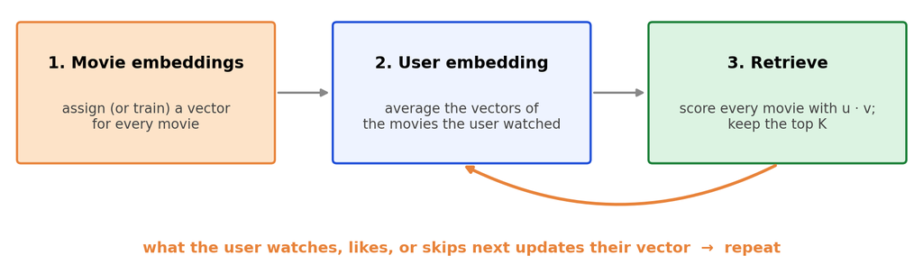

**Two differences from the old approach:**

|  | **Old approach** (KNN on ratings) | **New approach** (embeddings) |
| --- | --- | --- |
| **1. Similarity between** | user and user (user-based), or movie and movie (item-based) | **the user and each movie**: both are points in the same space |
| **2. Similarity measure** | cosine similarity | **dot product** $\mathbf{u}\cdot\mathbf{v}$ |

No neighbors to find and no ratings to average: score every movie directly against the user’s vector and **retrieve** the top $K$. Next: the three steps by hand.

## Step 1: Describe Each Movie With Two Numbers

| Movie | Number 1: funny (0 to 2) | Number 2: action-packed (0 to 2) | Kind |
| --- | --- | --- | --- |
| Elf | 2.0 | 0.2 | comedy |
| Paddington | 1.6 | 0.4 | comedy |
| John Wick | 0.2 | 2.0 | action |
| Mad Max | 0.4 | 1.6 | action |
| Shrek | 1.6 | 1.4 | both |
| The Incredibles | 1.4 | 1.8 | both |
| The Notebook | 0.2 | 0.2 | neither |
| Titanic | 0.4 | 0.6 | neither |

- Score each movie on two traits: **funny** and **action-packed**.
- *Elf* $= (2.0, 0.2)$: very funny. *John Wick* $= (0.2, 2.0)$: all action.
- That pair of numbers is the movie’s **embedding**.

**In practice**, a movie’s embedding is much longer: typically **64 to 256 numbers**, learned from data rather than scored by hand. YouTube’s 2016 system used **256** numbers per video. We use 2 so we can draw the picture and calculate by hand.

## The Movies as Points

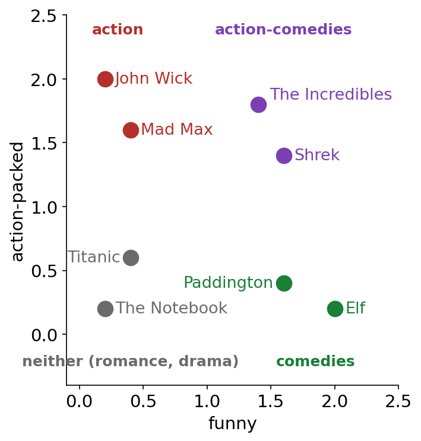

- **Close means alike:** comedies sit together, action films sit together.

- Real systems use 64 to 256 numbers, **learned** from watch data (how they are trained).

## Steps 2–3: The User’s Vector and Scores (Click to Step Through)

| Movie | (funny, action) | Watched? |
| --- | --- | --- |
| Elf | (2.0, 0.2) |  |
| Paddington | (1.6, 0.4) | **yes** |
| John Wick | (0.2, 2.0) |  |
| Mad Max | (0.4, 1.6) |  |
| Shrek | (1.6, 1.4) | **yes** |
| The Incredibles | (1.4, 1.8) |  |
| The Notebook | (0.2, 0.2) |  |
| Titanic | (0.4, 0.6) | **yes** |

**The user = average of the 3 watched:**

$$\begin{aligned}\mathbf{u} &= \dfrac{(1.6, 0.4) + (1.6, 1.4) + (0.4, 0.6)}{3} \\ &= \dfrac{(3.6,\ 2.4)}{3} = (1.2,\ 0.8)\end{aligned}$$

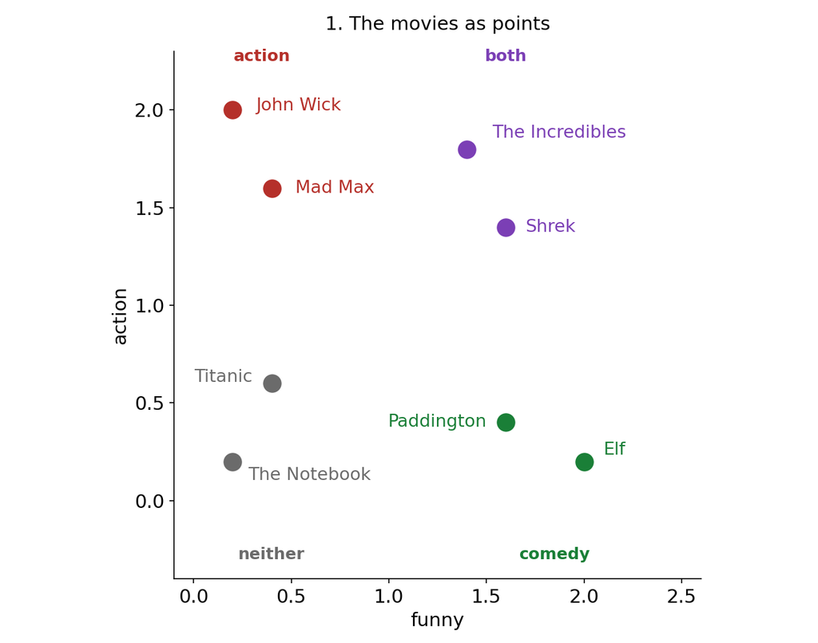

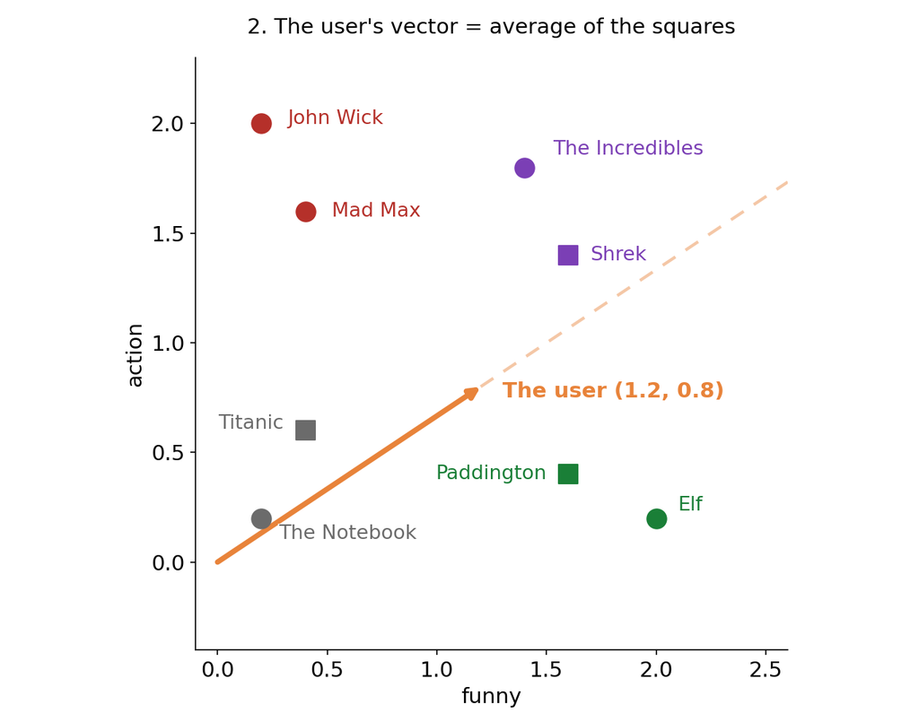

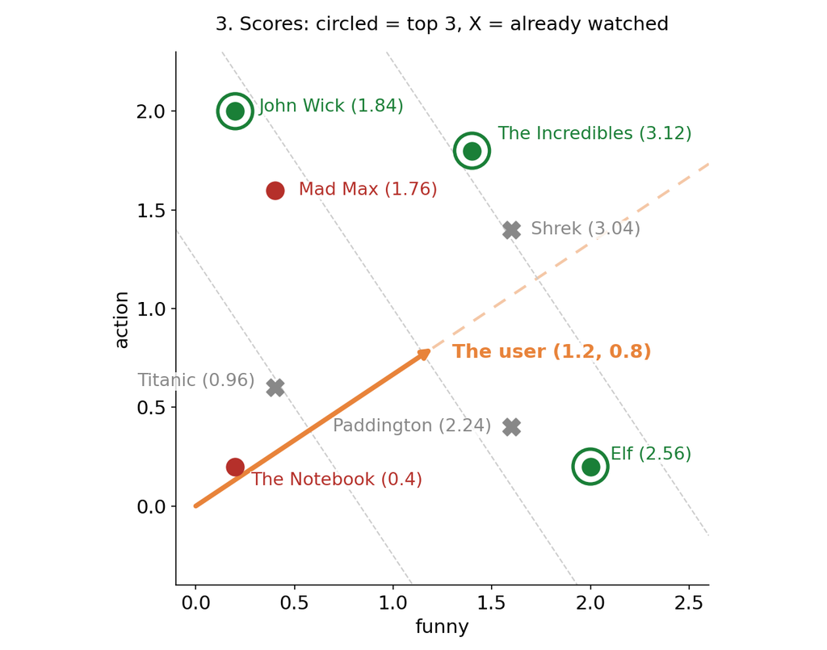

$\text{score} = 1.2 \times \text{funny} + 0.8 \times \text{action}$

| Movie | Calculation | Score | Rank |
| --- | --- | --- | --- |
| **The Incredibles** | 1.2(1.4) + 0.8(1.8) | 3.12 | **#1 ✓** |
| Shrek | 1.2(1.6) + 0.8(1.4) | 3.04 | done: skip |
| **Elf** | 1.2(2.0) + 0.8(0.2) | 2.56 | **#2 ✓** |
| Paddington | 1.2(1.6) + 0.8(0.4) | 2.24 | done: skip |
| **John Wick** | 1.2(0.2) + 0.8(2.0) | 1.84 | **#3 ✓** |
| Mad Max | 1.2(0.4) + 0.8(1.6) | 1.76 | #4 |
| Titanic | 1.2(0.4) + 0.8(0.6) | 0.96 | done: skip |
| The Notebook | 1.2(0.2) + 0.8(0.2) | 0.4 | #5 |

**Recommend: The Incredibles, Elf, John Wick.**

## Step 4: Why the Dot Product Works (a Picture)

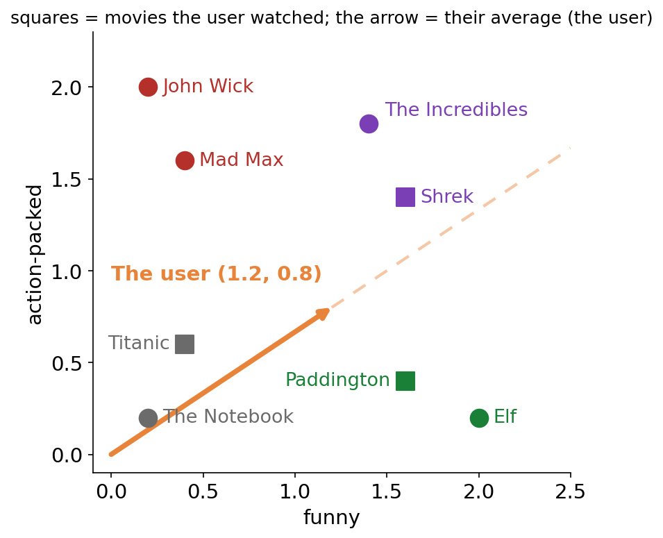

- A movie scores high when it lies **far along the user’s arrow**: *The Incredibles* is furthest, *The Notebook* barely along it.

## What Does the Dot Product Measure?

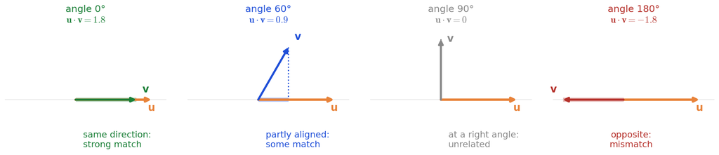

- **Definition:** multiply matching entries and add: $\mathbf{u}\cdot\mathbf{v} = u_1v_1 + u_2v_2 = \lVert\mathbf{u}\rVert\,\lVert\mathbf{v}\rVert\cos\theta$

- **Example:** the user’s embedding $\mathbf{u} = (1.2, 0.8)$ and *The Incredibles*’s embedding $\mathbf{v} = (1.4, 1.8)$:
  $$\mathbf{u}\cdot\mathbf{v} = (1.2)(1.4) + (0.8)(1.8) = 1.68 + 1.44 = 3.12$$

- **Meaning:** how much the arrows point the same way, times how long they are. The shaded bar shows how far $\mathbf{v}$ reaches along $\mathbf{u}$.

## Why the Dot Product, Not Cosine?

| Movie the user has not seen | Embedding | Length | Dot product | Cosine |
| --- | --- | --- | --- | --- |
| The Incredibles | (1.4, 1.8) | 2.28 | **3.12** (#1) | 0.949 (#2) |
| Elf | (2.0, 0.2) | 2.01 | **2.56** (#2) | 0.883 (#3) |
| John Wick | (0.2, 2.0) | 2.01 | **1.84** (#3) | 0.635 |
| Mad Max | (0.4, 1.6) | 1.65 | **1.76** | 0.74 |
| The Notebook | (0.2, 0.2) | 0.28 | **0.4** | 0.981 (#1) |

- $\mathbf{u}\cdot\mathbf{v} = \lVert\mathbf{u}\rVert\,\lVert\mathbf{v}\rVert\cos\theta$. **Cosine keeps only the angle** and throws away the lengths.

- With cosine, *The Notebook* would be **#1**: it points the same way as the user, but it is tiny (0.2, 0.2): barely funny, barely action.

- The dot product puts it **last**: a movie must point the user’s way **and** be strong on those traits.

In **learned** embeddings, length carries information: a long movie vector = strongly has the traits (and often **popular**); a long user vector = **strong** preferences. Training fits $\hat r = \mathbf{u}\cdot\mathbf{v}$, so retrieval uses the **same** score. Raw star ratings (old approach) were never trained this way, so there length only means “generous rater”: use cosine.

# Part 4. More Examples: Songs, Books, and TV Shows

## Example 2: Songs (Click to Step Through)

| Song | (energetic, acoustic) | Played? |
| --- | --- | --- |
| Uptown Funk | (2.0, 0.1) |  |
| Blinding Lights | (1.7, 0.4) |  |
| Hallelujah | (0.2, 1.9) | **yes** |
| Fast Car | (0.5, 1.6) |  |
| Mr. Brightside | (1.6, 0.8) | **yes** |
| Ho Hey | (1.2, 1.8) |  |
| Weightless | (0.3, 0.3) | **yes** |
| Teardrop | (0.5, 0.2) |  |

**The user = average of the 3 played:**

$$\begin{aligned}\mathbf{u} &= \dfrac{(0.2, 1.9) + (1.6, 0.8) + (0.3, 0.3)}{3} \\ &= \dfrac{(2.1,\ 3.0)}{3} = (0.7,\ 1)\end{aligned}$$

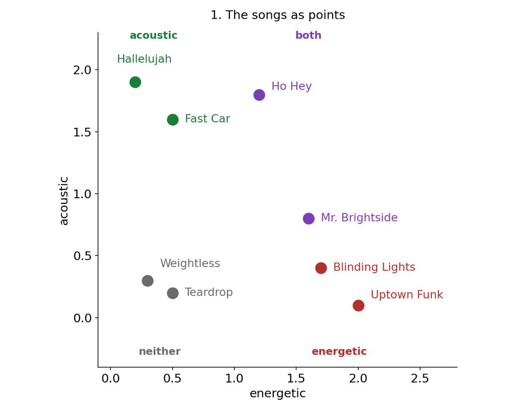

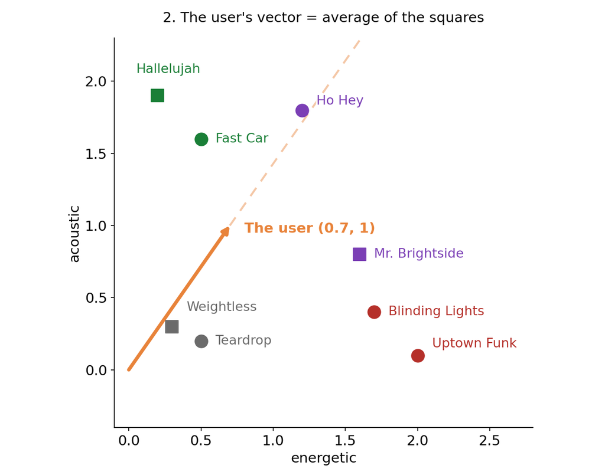

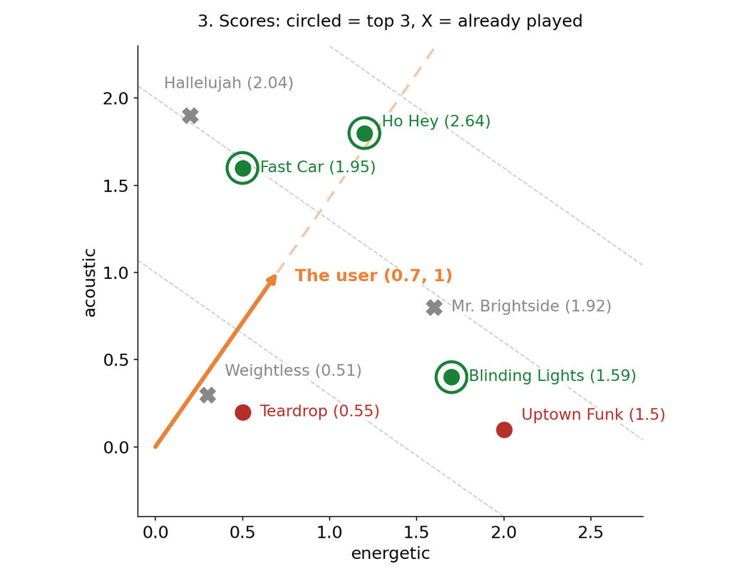

$\text{score} = 0.7 \times \text{energetic} + 1 \times \text{acoustic}$

| Song | Calculation | Score | Rank |
| --- | --- | --- | --- |
| **Ho Hey** | 0.7(1.2) + 1(1.8) | 2.64 | **#1 ✓** |
| Hallelujah | 0.7(0.2) + 1(1.9) | 2.04 | done: skip |
| **Fast Car** | 0.7(0.5) + 1(1.6) | 1.95 | **#2 ✓** |
| Mr. Brightside | 0.7(1.6) + 1(0.8) | 1.92 | done: skip |
| **Blinding Lights** | 0.7(1.7) + 1(0.4) | 1.59 | **#3 ✓** |
| Uptown Funk | 0.7(2.0) + 1(0.1) | 1.5 | #4 |
| Teardrop | 0.7(0.5) + 1(0.2) | 0.55 | #5 |
| Weightless | 0.7(0.3) + 1(0.3) | 0.51 | done: skip |

**Recommend: Ho Hey, Fast Car, Blinding Lights.**

## Example 3: Books (Click to Step Through)

| Book | (mystery, romance) | Read? |
| --- | --- | --- |
| Gone Girl | (2.0, 0.2) |  |
| The Da Vinci Code | (1.8, 0.4) | **yes** |
| Me Before You | (0.2, 1.9) |  |
| Pride and Prejudice | (0.5, 1.6) |  |
| Rebecca | (1.3, 1.7) |  |
| Twilight | (1.0, 1.4) | **yes** |
| Atomic Habits | (0.2, 0.3) | **yes** |
| Sapiens | (0.5, 0.2) |  |

**The user = average of the 3 read:**

$$\begin{aligned}\mathbf{u} &= \dfrac{(1.8, 0.4) + (1, 1.4) + (0.2, 0.3)}{3} \\ &= \dfrac{(3.0,\ 2.1)}{3} = (1,\ 0.7)\end{aligned}$$

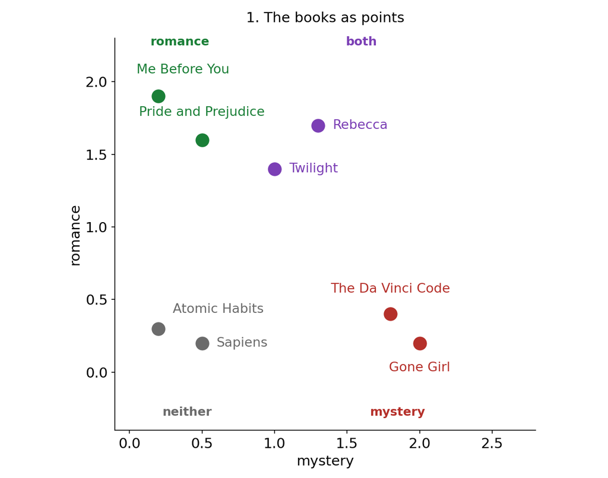

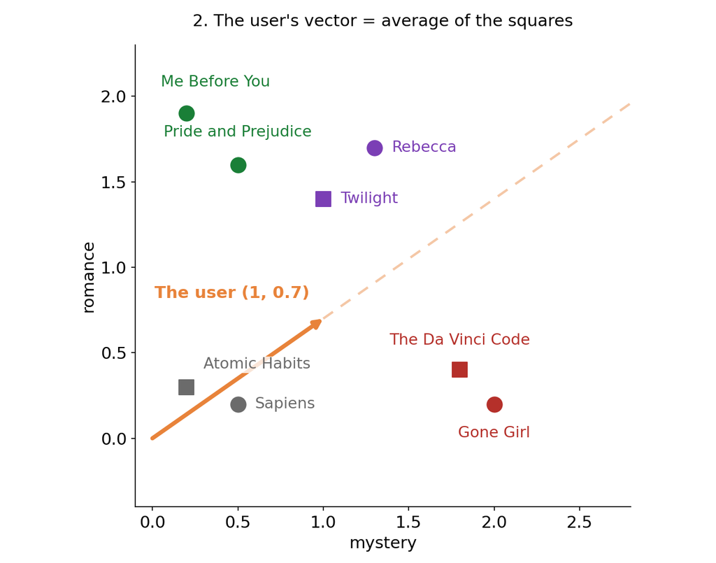

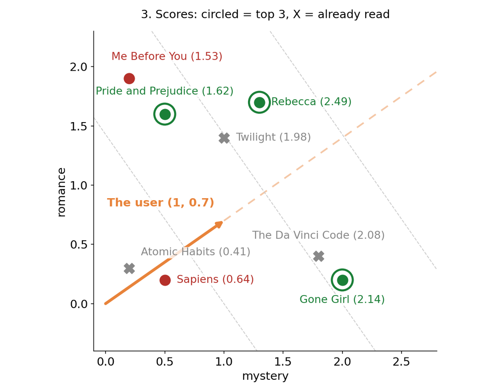

$\text{score} = 1 \times \text{mystery} + 0.7 \times \text{romance}$

| Book | Calculation | Score | Rank |
| --- | --- | --- | --- |
| **Rebecca** | 1(1.3) + 0.7(1.7) | 2.49 | **#1 ✓** |
| **Gone Girl** | 1(2.0) + 0.7(0.2) | 2.14 | **#2 ✓** |
| The Da Vinci Code | 1(1.8) + 0.7(0.4) | 2.08 | done: skip |
| Twilight | 1(1.0) + 0.7(1.4) | 1.98 | done: skip |
| **Pride and Prejudice** | 1(0.5) + 0.7(1.6) | 1.62 | **#3 ✓** |
| Me Before You | 1(0.2) + 0.7(1.9) | 1.53 | #4 |
| Sapiens | 1(0.5) + 0.7(0.2) | 0.64 | #5 |
| Atomic Habits | 1(0.2) + 0.7(0.3) | 0.41 | done: skip |

**Recommend: Rebecca, Gone Girl, Pride and Prejudice.**

## Example 4: TV Shows (Click to Step Through)

| Show | (funny, scary) | Watched? |
| --- | --- | --- |
| The Office | (2.0, 0.1) | **yes** |
| Friends | (1.8, 0.4) |  |
| The Walking Dead | (0.2, 1.8) | **yes** |
| Black Mirror | (0.4, 1.5) |  |
| Stranger Things | (1.3, 1.5) |  |
| Wednesday | (1.5, 1.1) |  |
| The Crown | (0.2, 0.3) |  |
| Planet Earth | (0.5, 0.2) | **yes** |

**The user = average of the 3 watched:**

$$\begin{aligned}\mathbf{u} &= \dfrac{(2, 0.1) + (0.2, 1.8) + (0.5, 0.2)}{3} \\ &= \dfrac{(2.7,\ 2.1)}{3} = (0.9,\ 0.7)\end{aligned}$$

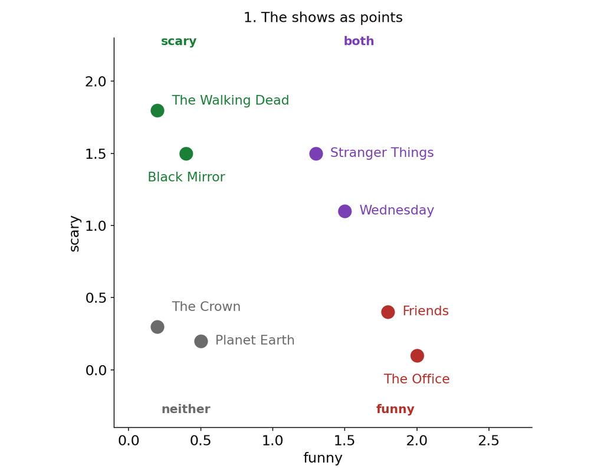

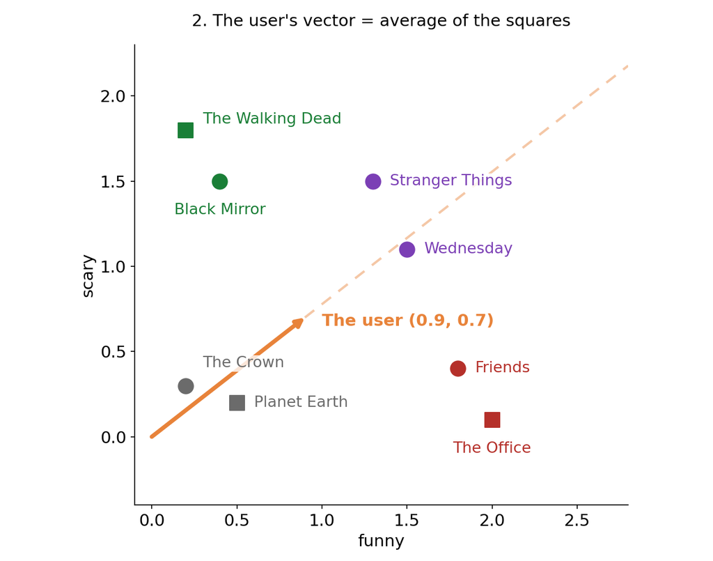

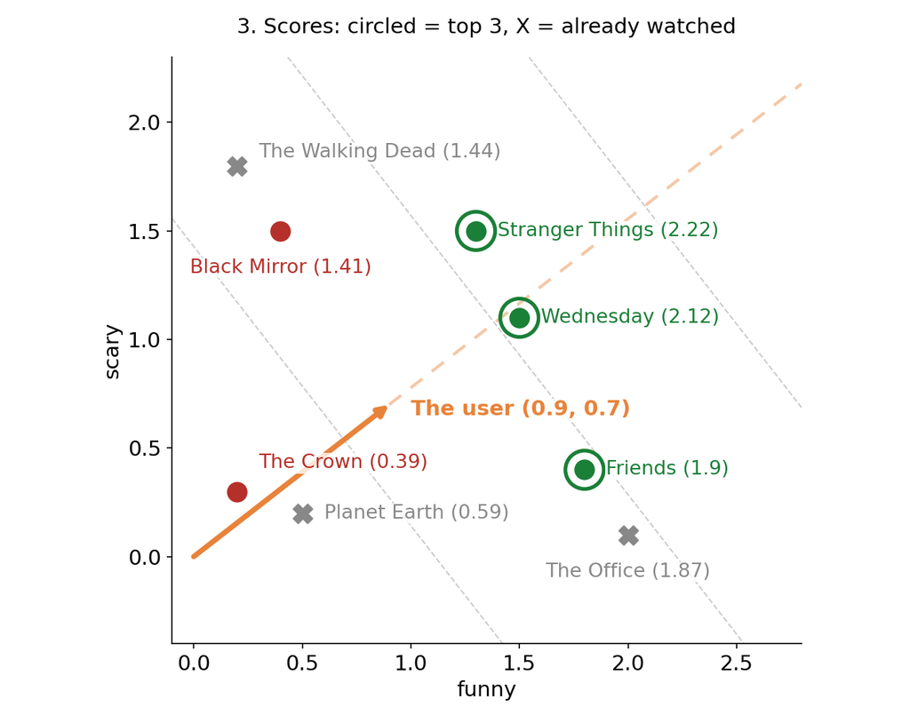

$\text{score} = 0.9 \times \text{funny} + 0.7 \times \text{scary}$

| Show | Calculation | Score | Rank |
| --- | --- | --- | --- |
| **Stranger Things** | 0.9(1.3) + 0.7(1.5) | 2.22 | **#1 ✓** |
| **Wednesday** | 0.9(1.5) + 0.7(1.1) | 2.12 | **#2 ✓** |
| **Friends** | 0.9(1.8) + 0.7(0.4) | 1.9 | **#3 ✓** |
| The Office | 0.9(2.0) + 0.7(0.1) | 1.87 | done: skip |
| The Walking Dead | 0.9(0.2) + 0.7(1.8) | 1.44 | done: skip |
| Black Mirror | 0.9(0.4) + 0.7(1.5) | 1.41 | #4 |
| Planet Earth | 0.9(0.5) + 0.7(0.2) | 0.59 | done: skip |
| The Crown | 0.9(0.2) + 0.7(0.3) | 0.39 | #5 |

**Recommend: Stranger Things, Wednesday, Friends.**

# Practice Problem

## Practice Problem: Build the User’s Vector, Then Retrieve

A podcast app gives every podcast a 2-number embedding (number 1: news and business, number 2: comedy and stories). **These podcast embeddings were learned beforehand** by the app’s model from all users’ listening data, so in this problem they are **known**. Only the user’s embedding must be computed.

| Podcast | Embedding (news, comedy) |
| --- | --- |
| Podcast A | (0.8, 0.2) |
| Podcast B | (0.2, 0.9) |
| Podcast C | (0.6, 0.6) |
| Podcast D | (0.1, 0.4) |
| Podcast E | (0.9, 0.8) |
| Podcast F | (0.1, 1.2) |

Last month **the user** listened to **Podcast E** and **Podcast F**.

1. Compute **the user’s embedding** as the **average** of the podcasts they listened to.
2. Score every podcast with the **dot product**. Recommend the top 2 that the user has **not** heard.

## Solution (a) and (b): The User’s Vector and Top 2 (Click to Step Through)

| Podcast | (news, comedy) | Weight |
| --- | --- | --- |
| A | (0.8, 0.2) |  |
| B | (0.2, 0.9) |  |
| C | (0.6, 0.6) |  |
| D | (0.1, 0.4) |  |
| E | (0.9, 0.8) | **1** (heard) |
| F | (0.1, 1.2) | **1** (heard) |

**The user = average of the 2 they heard:**

$$\begin{aligned}\mathbf{u} &= \dfrac{(0.9, 0.8) + (0.1, 1.2)}{2} \\ &= \dfrac{(1.0,\ 2.0)}{2} = (0.5,\ 1)\end{aligned}$$

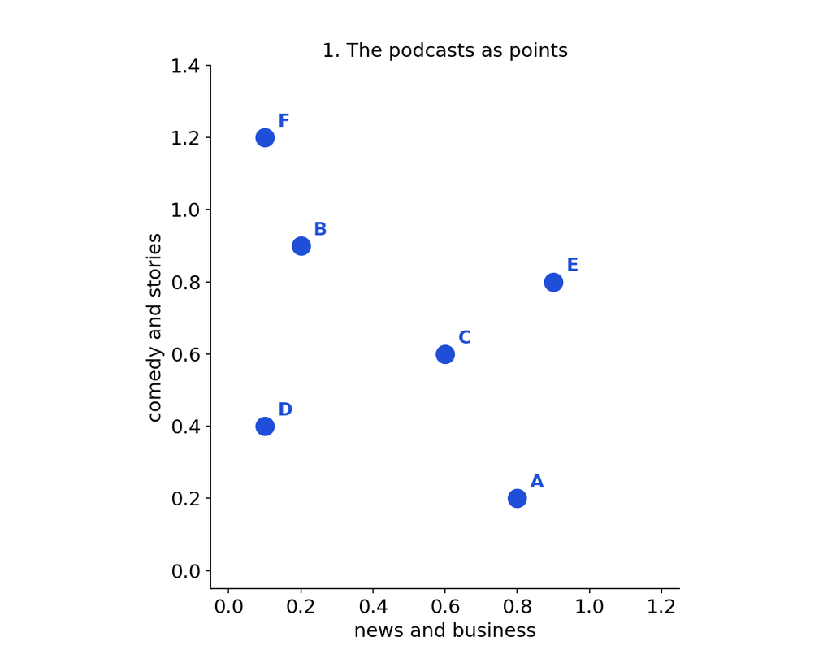

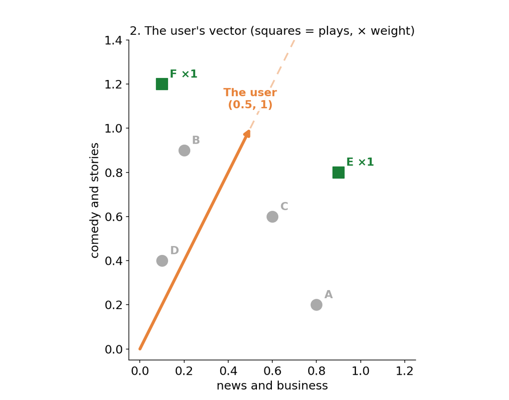

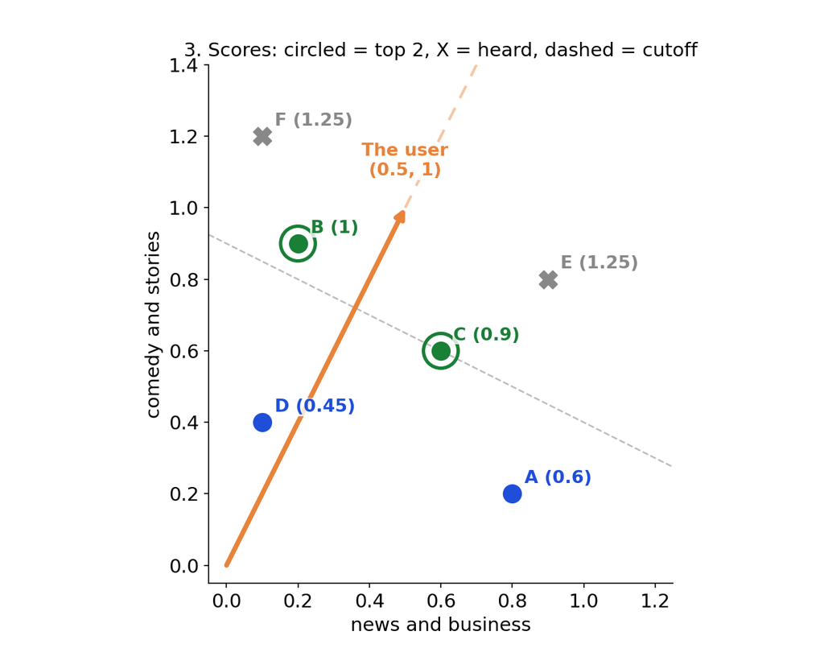

$\text{score} = 0.5 \times \text{news} + 1 \times \text{comedy}$

| Podcast | Calculation | Score | Rank |
| --- | --- | --- | --- |
| E | 0.5(0.9) + 1(0.8) | 1.25 | heard: skip |
| F | 0.5(0.1) + 1(1.2) | 1.25 | heard: skip |
| **B** | 0.5(0.2) + 1(0.9) | 1 | **#1 ✓** |
| **C** | 0.5(0.6) + 1(0.6) | 0.9 | **#2 ✓** |
| A | 0.5(0.8) + 1(0.2) | 0.6 | #3 |
| D | 0.5(0.1) + 1(0.4) | 0.45 | #4 |

**Recommend: B and C.** (E and F score higher, but the user already heard them.)

## Practice Problem, Round 2: One Week Later

| New this week | Embedding (also learned beforehand) |
| --- | --- |
| Podcast G | (1.0, 0.5) |
| Podcast H | (0.1, 1.0) |
| Podcast I | (0.7, 0.9) |

The user played **Podcast C** (one of our picks) and **Podcast D** (which we did not recommend); they skipped Podcast B. Three **new** podcasts (G, H, I) were also released this week.

3. Recompute the user’s embedding as a **weighted average** of their 4 plays: older plays (E, F) count **1**, this week’s plays (C, D) count **2**. Score the 5 podcasts they have not heard (A, B, G, H, I) and recommend the top 2.
4. The user also gave **feedback**: they **liked** Podcast D and tapped **“not interested”** on Podcast C. The app doubles the weight of a liked play and gives a “not interested” play weight **−1**. Recompute their embedding and their top 2.

## Solution (c): Recent Plays Count More (Click to Step Through)

| Podcast | (news, comedy) | Weight |
| --- | --- | --- |
| A | (0.8, 0.2) |  |
| B | (0.2, 0.9) |  |
| C | (0.6, 0.6) | **2** (this week) |
| D | (0.1, 0.4) | **2** (this week) |
| E | (0.9, 0.8) | **1** (older) |
| F | (0.1, 1.2) | **1** (older) |
| G | (1.0, 0.5) | new |
| H | (0.1, 1.0) | new |
| I | (0.7, 0.9) | new |

**The user = weighted average.** Weights: E ×1, F ×1, C ×2, D ×2; total = 6.

$$\begin{aligned}\mathbf{u} &= \dfrac{(0.9, 0.8) + (0.1, 1.2) + 2(0.6, 0.6) + 2(0.1, 0.4)}{6} \\ &= \dfrac{(2.4,\ 4.0)}{6} = (0.4,\ 0.667)\end{aligned}$$

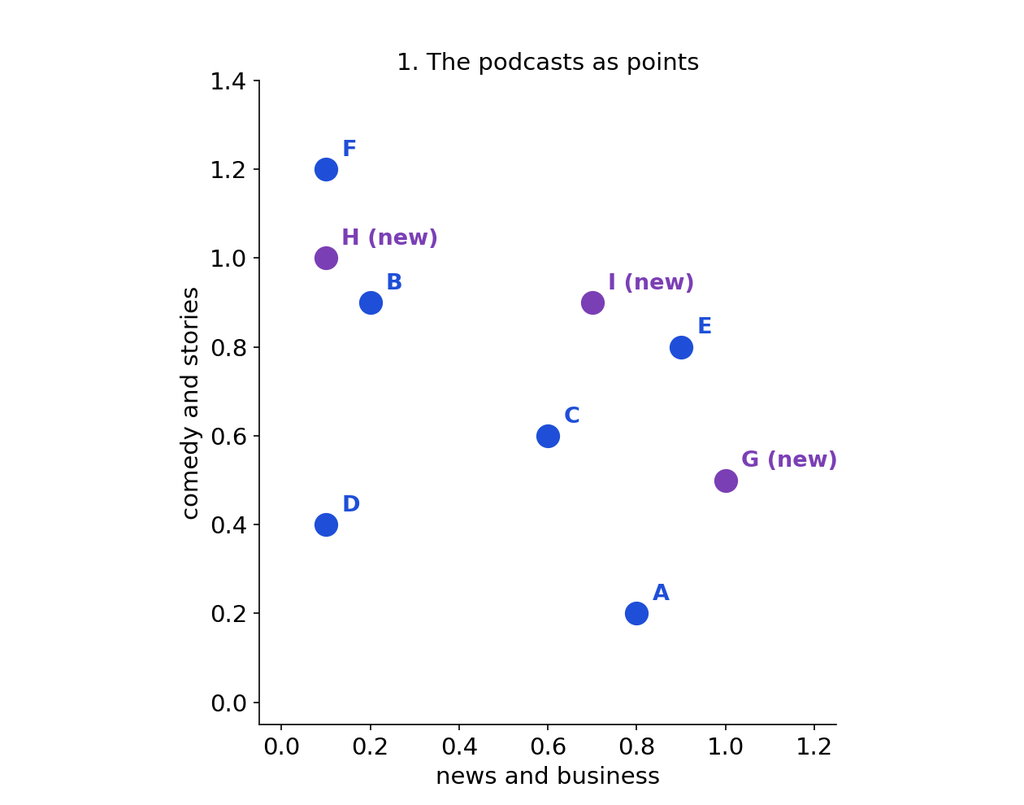

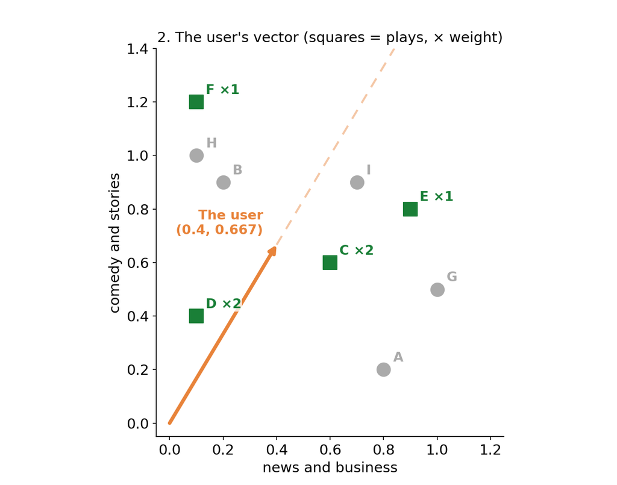

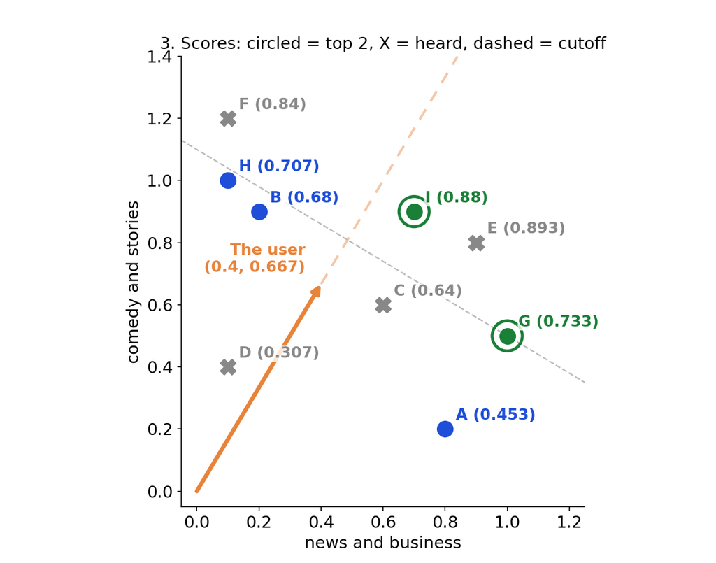

$\text{score} = 0.4 \times \text{news} + 0.667 \times \text{comedy}$

| Podcast | Calculation | Score | Rank |
| --- | --- | --- | --- |
| E | 0.4(0.9) + 0.667(0.8) | 0.893 | heard: skip |
| **I** | 0.4(0.7) + 0.667(0.9) | 0.88 | **#1 ✓** |
| F | 0.4(0.1) + 0.667(1.2) | 0.84 | heard: skip |
| **G** | 0.4(1) + 0.667(0.5) | 0.733 | **#2 ✓** |
| H | 0.4(0.1) + 0.667(1) | 0.707 | #3 |
| B | 0.4(0.2) + 0.667(0.9) | 0.68 | #4 |
| C | 0.4(0.6) + 0.667(0.6) | 0.64 | heard: skip |
| A | 0.4(0.8) + 0.667(0.2) | 0.453 | #5 |
| D | 0.4(0.1) + 0.667(0.4) | 0.307 | heard: skip |

**Recommend: I and G.** The user’s vector moved toward C and D, their newest plays.

## Solution (d): Feedback Changes the Weights (Click to Step Through)

| Podcast | (news, comedy) | Weight |
| --- | --- | --- |
| A | (0.8, 0.2) |  |
| B | (0.2, 0.9) |  |
| C | (0.6, 0.6) | **(−1)** (not interested) |
| D | (0.1, 0.4) | **4** (this week, liked) |
| E | (0.9, 0.8) | **1** (older) |
| F | (0.1, 1.2) | **1** (older) |
| G | (1.0, 0.5) | new |
| H | (0.1, 1.0) | new |
| I | (0.7, 0.9) | new |

**The user = weighted average.** Weights: E ×1, F ×1, C ×(−1), D ×4; total = 5.

$$\begin{aligned}\mathbf{u} &= \dfrac{(0.9, 0.8) + (0.1, 1.2) - (0.6, 0.6) + 4(0.1, 0.4)}{5} \\ &= \dfrac{(0.8,\ 3.0)}{5} = (0.16,\ 0.6)\end{aligned}$$

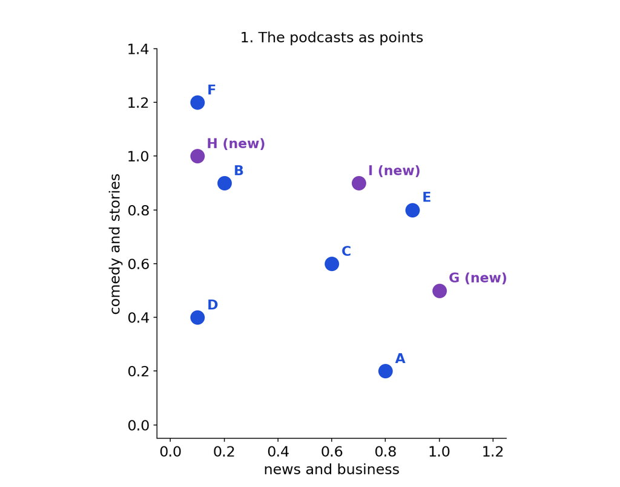

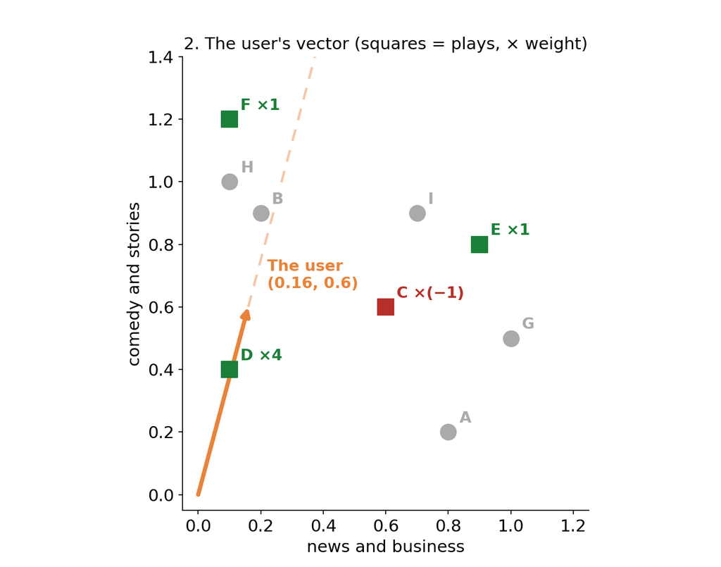

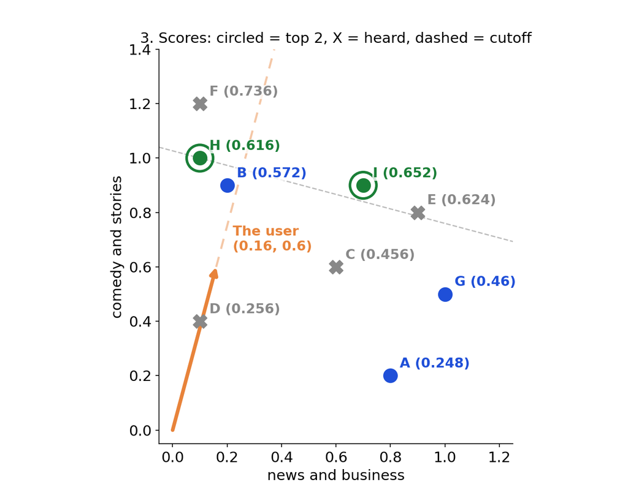

$\text{score} = 0.16 \times \text{news} + 0.6 \times \text{comedy}$

| Podcast | Calculation | Score | Rank |
| --- | --- | --- | --- |
| F | 0.16(0.1) + 0.6(1.2) | 0.736 | heard: skip |
| **I** | 0.16(0.7) + 0.6(0.9) | 0.652 | **#1 ✓** |
| E | 0.16(0.9) + 0.6(0.8) | 0.624 | heard: skip |
| **H** | 0.16(0.1) + 0.6(1) | 0.616 | **#2 ✓** |
| B | 0.16(0.2) + 0.6(0.9) | 0.572 | #3 |
| G | 0.16(1) + 0.6(0.5) | 0.46 | #4 |
| C | 0.16(0.6) + 0.6(0.6) | 0.456 | heard: skip |
| D | 0.16(0.1) + 0.6(0.4) | 0.256 | heard: skip |
| A | 0.16(0.8) + 0.6(0.2) | 0.248 | #5 |

**Recommend: I and H.** Feedback swapped G (news) for H (stories): the user rejected C and liked D.

## The User’s Embedding Over Time (Click to Step Through)

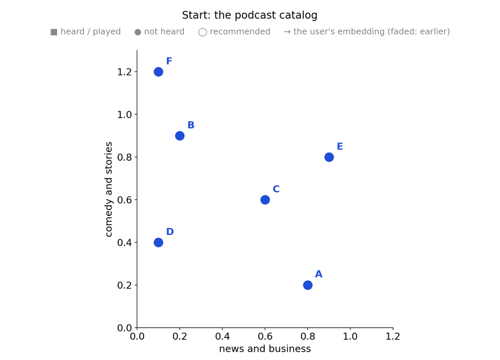

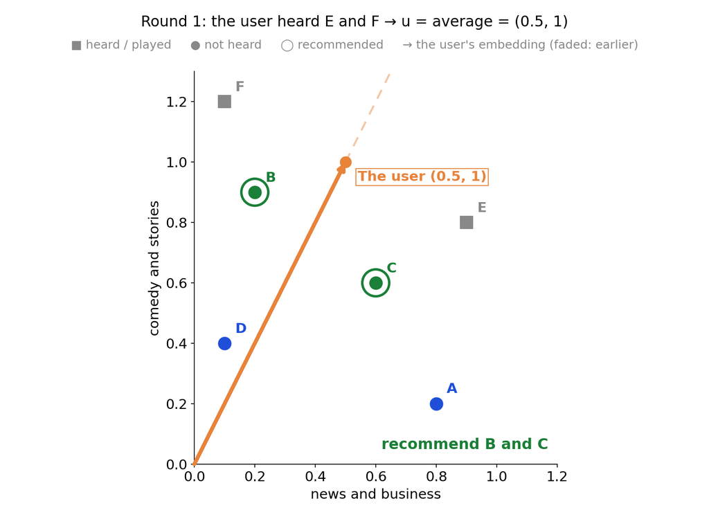

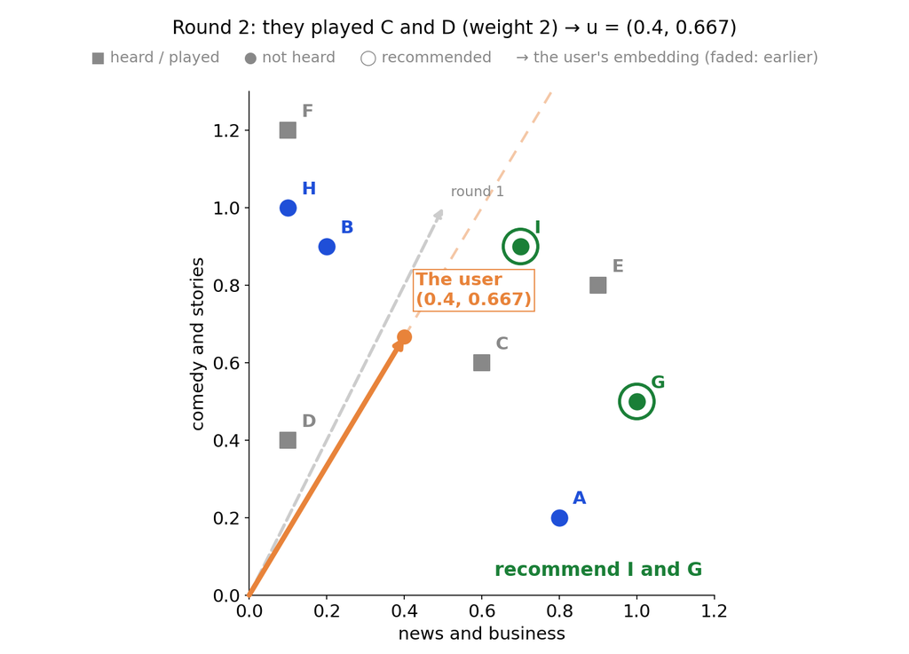

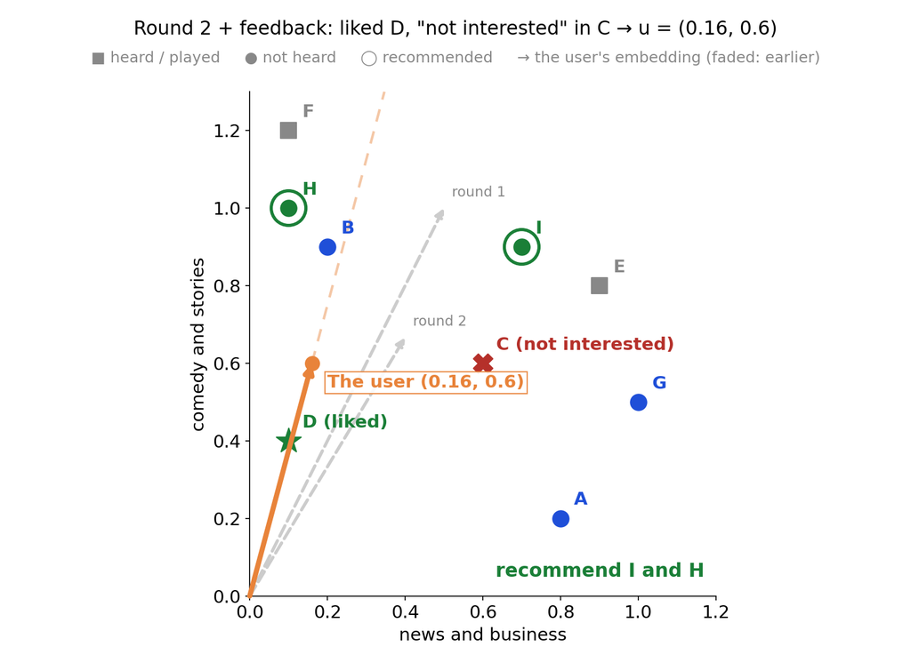

## Our Practice Problem vs. a Modern Recommender

|  | **Practice problem** (podcasts) | **Modern recommender** (YouTube, TikTok, Spotify) |
| --- | --- | --- |
| Catalog | 9 podcasts | millions to billions of videos or songs |
| Item embeddings | 2 numbers, **given** (learned beforehand) | 64 to 256+ numbers, **learned** from billions of plays; retrained daily or weekly |
| User embedding | **average** of what the user played | a **neural network** (two-tower or transformer) reads the watch history plus context (time, device, searches) |
| Recency and feedback | **fixed weights we chose**: 2 for this week, ×2 liked, −1 “not interested” | **learned** from data: watch time, likes, skips, shares, “not interested” |
| Retrieval | score **every** podcast with $\mathbf{u}\cdot\mathbf{v}$, keep the top 2 | **approximate** nearest-neighbor search, keep the top few hundred; several candidate sources (similar items, subscriptions, trending) |
| Ranking | none: the top 2 **are** the recommendations | a second, larger model **re-ranks** the candidates (predicted watch time, like, share), then rules for diversity, freshness and safety |
| Updates | recompute by hand one week later | user vector recomputed at **every request**; item vectors retrained on new data |

**What stays the same:** items and users are vectors in the same space, the user’s vector comes from their history, retrieval keeps the items with the largest $\mathbf{u}\cdot\mathbf{v}$, and what the user does next feeds back into the next round.